# An excess of Cronbach’s α values at rule-of-thumb cut-offs

Analyses of Psychology/APA dataset

Ian Hussey

26 July, 2024

# Dependencies

```r
library(tidyverse)
library(scales)
library(betareg)
library(broom)
library(extraDistr)
library(patchwork)
library(coin)
library(knitr)
library(kableExtra)
library(ggtext)


dir.create("plots")

# disable scientific notation
options(scipen=999)

# set seed
set.seed(42)
```

# Get data

```r
data_processed <- read_csv("../../data/processed/psychology/data_processed_psychology.csv") %>%
  # round the alpha values to 2 decimal places, using standard rounding method
  # recode alpha values of 0 or 1 to .01 or .99, in order to be able to fit beta regression
  # nb none present in dataset
  mutate(alpha = janitor::round_half_up(alpha, 2),
         alpha = case_when(alpha == 0 ~ 0.01,
                           alpha == 1 ~ 0.99,
                           TRUE ~ alpha))

data_processed_trimmed <- data_processed |>
  filter(!is.na(alpha) & exclude_master == FALSE)
```

# Descriptives

```r
# data_fulltexts <-
#   tibble(filename = list.files("../../data/apa_articles",
#                                pattern    = "*.txt",
#                                recursive  = TRUE,
#                                full.names = TRUE))
#
# n_doi <- nrow(data_fulltexts)
# n_doi$n_doi
# # [1] 74470

n_doi <- 74470

cat("n articles =",
      n_doi, "\n")
```

```
## n articles = 74470
```

```r
n_exclusions <- data_processed |>
  count(name = "n_exclusions") |>
  pull(n_exclusions)

cat("n exclusions =", n_exclusions, "\n")
```

```
## n exclusions = 60153
```

```r
n_estimates_after_exclusions <- data_processed_trimmed |>
  count(name = "n_estimates") |>
  pull(n_estimates)

cat("n alpha estimates after exclusions =",
      n_estimates_after_exclusions, "\n")
```

```
## n alpha estimates after exclusions = 33409
```

```r
dois_with_valid_alpha <- nrow(distinct(data_processed_trimmed, doi))

cat("n articles with 1+ alpha estimate after exclusions = ", dois_with_valid_alpha, "\n")
```

```
## n articles with 1+ alpha estimate after exclusions =  11976
```

```r
proportion_with_valid_alpha <-
  janitor::round_half_up(dois_with_valid_alpha / n_doi*100, 1)

cat("proportion of articles with 1+ alpha estimates after exclusions =",
      proportion_with_valid_alpha, "\n")
```

```
## proportion of articles with 1+ alpha estimates after exclusions = 16.1
```

# Kernel smoothing

## Model and plot

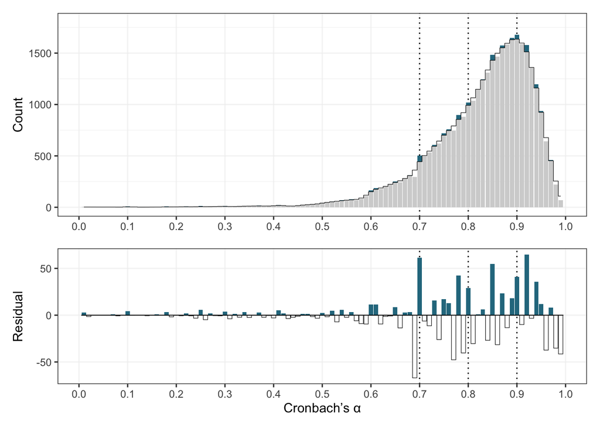

```r
# create tibble containing all alpha bins, for a later join
all_alphas <- tibble(alpha = as.character(seq(0.01, 0.99, 0.01)),
                     freq = 0,
                     missing = TRUE)

data_frequency_temp <- data_processed_trimmed %>%
  mutate(n_total = n()) %>%
  group_by(alpha) %>%
  summarise(freq = sum(!is.na(alpha))/first(n_total)) %>%
  # convert alpha to character to facilitate a join later
  mutate(alpha = as.character(alpha))

# kernel density estimation
data_density <-
  density(data_processed_trimmed %>%
            pull(alpha),
          n      = length(seq(0.01, 0.99, 0.01)),
          from   = 0.01,
          to     = 0.99,
          kernel = "gaussian",
          bw     = 0.01) # "nrd0" returns 0.01

data_frequency <-
  # join the previous two tibbles to create a complete list of alpha bins
  data_frequency_temp %>%
  bind_rows(all_alphas %>% anti_join(data_frequency_temp, by = "alpha")) %>%
  arrange(alpha, desc(freq)) %>%
  distinct(alpha, .keep_all = TRUE) %>%
  mutate(density_kernel = data_density$y,
         missing = ifelse(is.na(missing), FALSE, missing)) %>%
  mutate(residual_kernel = freq*100 - density_kernel,
         alpha = as.numeric(alpha),
         missing = ifelse(is.na(missing), FALSE, missing))

total_n <- nrow(data_processed_trimmed)/100

plot_data_psych <- data_processed_trimmed |>
  mutate(n_total = n()) |>
  group_by(alpha) |>
  summarise(count = sum(!is.na(alpha))) |>
  mutate(type = case_when(alpha %in% c(.70, .80, .90) ~ "Common reliability threshold",
                          TRUE ~ "Non-threshold"),
         type = fct_relevel(type, "Non-threshold", "Common reliability threshold")) |>
  right_join(data_frequency, by = "alpha") |>
  mutate(excess = if_else(residual_kernel > 0, "excess", "deficit")) %>%
  drop_na()

c_excess <- "#2A788EFF"
c_data <- "lightgrey"
c_line <- "black"
c_lpbg <- "white"
c_grid <- "#F0F0F0AA"

p1_kernel_psych <-
  ggplot(plot_data_psych, aes(alpha, y = count, fill = excess)) +
  geom_vline(xintercept = c(0.7, 0.8, 0.9), linetype = "dotted") +
  geom_col() +
  geom_col(aes(y = count - if_else(residual_kernel > 0, residual_kernel * total_n, 0)), fill = c_data) +
  geom_step(aes(y = density_kernel * total_n, group = 1), direction = "mid", size = 0.2, color = c_line) +
  scale_fill_manual(values = c(c_data, c_excess),
                    name = element_blank()) +
  scale_x_continuous(breaks = seq(from = 0, to = 1, by = 0.1),
                     labels = label_number(accuracy = 0.1),
                     minor_breaks = NULL) +
  theme_bw() +
  labs(x = "",
       y = "Count") +
  theme(axis.title.x = element_markdown()) +
  ylim(0, 1800) +
  theme(legend.position = "none",
        legend.background = element_blank(),
        panel.grid = element_line(color = c_grid))

p2_kernel_psych <-
  ggplot(plot_data_psych, aes(alpha, residual_kernel * total_n, fill = excess)) +
  geom_vline(xintercept = c(0.7, 0.8, 0.9), linetype = "dotted") +
  geom_col(aes(color = excess), size = 0.2) +
  scale_color_manual(values = c(c_line, "#FFFFFF00")) +
  geom_segment(x = 0.005, xend = 0.995, y = 0,yend=0, size = 0.2, color = c_line) +
  scale_fill_manual(values = c("white", c_excess),
                    guide = guide_legend(reverse = TRUE)) +
  scale_x_continuous(breaks = seq(from = 0, to = 1, by = 0.1),
                     labels = label_number(accuracy = 0.1),
                     minor_breaks = NULL) +
  scale_y_continuous(breaks = seq(from = -200, to = 200, by = 50),
                     labels = label_number(accuracy = 1),
                     minor_breaks = NULL) +
  theme_bw() +
  labs(x = "Cronbach's &alpha;",
       y = "Residual") +
  theme(legend.title = element_blank(),
        axis.title.x = element_markdown(),
        legend.position = "none",
        panel.background = element_rect(fill = c_lpbg),
        panel.grid = element_line(color = c_grid))  # c(0.23, 0.77), legend.background = element_blank()

p_kernel_psych <-
  p1_kernel_psych +
  p2_kernel_psych +
  plot_layout(nrow = 2, heights = c(1.5, 1))

p_kernel_psych
```

```r
write_rds(p_kernel_psych, "plots/p_kernel_psychology.rds")

ggsave("plots/p_kernel_psychology.pdf",
       plot = p_kernel_psych,
       device = cairo_pdf,
       width = 6,
       height = 4.5,
       units = "in")

ggsave("plots/p_kernel_psychology.png",
       plot = p_kernel_psych,
       device = png,
       width = 6,
       height = 4.5,
       dpi = 600,
       units = "in")
```

## Quantify excess

```r
data_inflation_kernel <- data_frequency %>%
  filter(missing == FALSE) %>%
  dplyr::select(alpha,
                observed = freq,
                predicted = density_kernel,
                residual = residual_kernel) %>%
  mutate(predicted = predicted/100,
         residual = residual/100,
         inflation = (observed/predicted - 1),
         inflation_for_reporting = janitor::round_half_up(inflation*100, digits = 0),
         group_3_cutoffs = as.factor(case_when(alpha %in% c(.70, .80, .90) ~ "cutoff",
                                               TRUE ~ "non cutoff")),
         group_1_cutoff = as.factor(case_when(alpha %in% c(.70) ~ "cutoff",
                                               TRUE ~ "non cutoff")))

write_csv(data_inflation_kernel, "plots/residuals_psychology.csv")
```

- There were 14% more observations of Cronbach’s $\alpha$ = .70 than predicted.
- There were 3% more observations of Cronbach’s $\alpha$ = .80 than predicted.
- There were 3% more observations of Cronbach’s $\alpha$ = .90 than predicted.

## Permutation tests

.70, .80, and .90 against the rest:

```r
independence_test(residual ~ group_3_cutoffs,
                  data = data_inflation_kernel,
                  distribution = "exact",
                  alternative = "greater")
```

```
##
##  Exact General Independence Test
##
## data:  residual by group_3_cutoffs (cutoff, non cutoff)
## Z = 3.94, p-value = 0.0003499
## alternative hypothesis: greater
```

.70 against the rest:

```r
independence_test(residual ~ group_1_cutoff,
                  data = data_inflation_kernel,
                  distribution = "exact",
                  alternative = "greater")
```

[output not shown]

# Caliper tests

See Gerber et al. (2010) “Publication Bias in Two Political Behavior Literatures”

Using alpha ± 0.01 calipers.

The usual null hypothesis of no differences cannot be tested against, so instead I calculate over/under ratios for each 0.01 and its neighbor, i.e., ratio = count($\alpha_x$) / count($\alpha_{x-0.01}$). Because very few counts are present in < .50, which makes the ratios very poorly estimated, I exclude these values. The hypothesis that the ratio for the cut-off score ratio being larger than the ratios calculated from non cut-offs is then tested via permuation test.

## Quantify excess

```r
data_caliper <- data_processed_trimmed %>%
  mutate(n_total = n()) %>%
  group_by(alpha) %>%
  summarise(count = sum(!is.na(alpha)))

data_caliper |>
  filter(alpha %in% c(.69, .70, .79, .80, .89, .90)) |>
  mutate(type = ifelse(alpha %in% c(.70, .80, .90), "threshold", "nonthreshold"),
         cutoff = case_when(alpha %in% c(.69, .70) ~ .70,
                            alpha %in% c(.79, .80) ~ .80,
                            alpha %in% c(.89, .90) ~ .90)) |>
  select(-alpha) |>
  pivot_wider(names_from = type,
              values_from = count) |>
  mutate(ratio = janitor::round_half_up(threshold/nonthreshold, 2)) |>
  kable() |>
  kable_classic(full_width = FALSE)
```

| cutoff | nonthreshold | threshold | ratio |
| --- | --- | --- | --- |
| 0.7 | 295 | 505 | 1.71 |
| 0.8 | 880 | 1021 | 1.16 |
| 0.9 | 1648 | 1677 | 1.02 |

```r
data_caliper_all <- data_caliper |>
  mutate(ratio = count/lag(count),
         group_3_cutoffs = as.factor(case_when(alpha %in% c(.70, .80, .90) ~ "cutoff",
                                               TRUE ~ "non cutoff")),
         group_1_cutoff = as.factor(case_when(alpha %in% c(.70) ~ "cutoff",
                                              TRUE ~ "non cutoff")))
```

## Plot

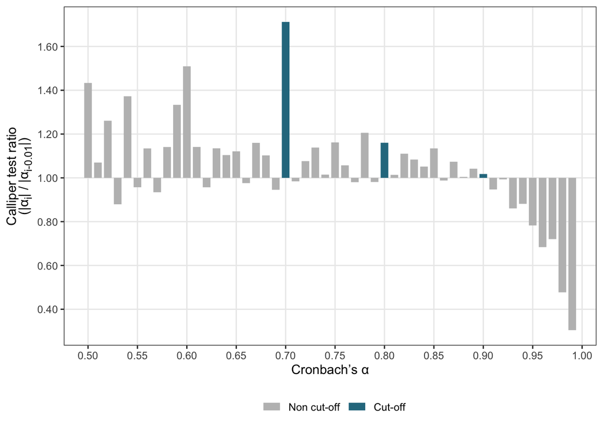

```r
cbp2 <- c("grey", "#2A788EFF")

p_caliper_all_psychology <-
  data_caliper_all |>
  filter(alpha >= .50) |>
  mutate(type = case_when(alpha %in% c(.70, .80, .90) ~ "Cut-off",
                          TRUE ~ "Non cut-off"),
         type = fct_relevel(type, "Non cut-off", "Cut-off")) |>
  #mutate(type = ifelse(ratio > 1, "1", "2")) |>
  ggplot(aes(x = alpha, y = ratio, fill = type, color = type)) +
  #geom_vline(xintercept = c(0.7, 0.8, 0.9), linetype = "dotted") +
  #geom_col(position = "stack") +
  geom_segment(aes(x = alpha,
                   xend = alpha,
                   y = 1,
                   yend = ratio), size = 3) +
  #scale_color_viridis_d(direction = -1, begin = 0.2, end = 0.6, option = "plasma") +
  #scale_color_viridis_d(direction = -1, begin = 0.2, end = 0.55, option = "magma") +
  scale_color_manual(values = cbp2) +
  scale_x_continuous(breaks = seq(from = 0, to = 1, by = 0.05),
                     labels = label_number(accuracy = 0.01),
                     minor_breaks = NULL) +
  scale_y_continuous(breaks = seq(from = 0, to = 2, by = 0.2),
                     labels = label_number(accuracy = 0.01),
                     minor_breaks = NULL) +
  theme_bw() +
  labs(x = "Cronbach's &alpha;",
       #y = "Ratio<br />n(&alpha;<sub>i</sub>) / n(&alpha;<sub>i-0.01</sub>)",
       y = "Calliper test ratio<br />(|&alpha;<sub>i</sub>| / |&alpha;<sub>i-0.01</sub>|)",
       color = "") +
  theme(legend.position = "bottom",
        axis.title.x = element_markdown(),
        axis.title.y = element_markdown())

p_caliper_all_psychology
```

```r
write_rds(p_caliper_all_psychology, "plots/p_caliper_all_psychology.rds")

ggsave("plots/p_caliper_all_psychology.pdf",
       plot = p_caliper_all_psychology,
       device = cairo_pdf,
       width = 6,
       height = 4,
       units = "in")
```

Note that $|\alpha_i|$ refers to cardinality (i.e., count) rather than absolute value. Unfortunately these are annotated in the same way using vertical bars.

## Permutation tests

.70/.69, .80/.79, and .90/.89 against the rest:

```r
independence_test(ratio ~ group_3_cutoffs,
                  data = filter(data_caliper_all, alpha >= .50),
                  distribution = "exact",
                  alternative = "greater")
```

```
##
##  Exact General Independence Test
##
## data:  ratio by group_3_cutoffs (cutoff, non cutoff)
## Z = 1.9712, p-value = 0.02617
## alternative hypothesis: greater
```

.70/.69 against the rest:

```r
independence_test(ratio ~ group_1_cutoff,
                  data = filter(data_caliper_all, alpha >= .50),
                  distribution = "exact",
                  alternative = "greater")
```

```
##
##  Exact General Independence Test
##
## data:  ratio by group_1_cutoff (cutoff, non cutoff)
## Z = 2.963, p-value = 0.02
## alternative hypothesis: greater
```

# Beta regression

Beta regression was also explored, but it had many more assumptions and poorer fit (e.g., large degree of unmodelled variance around $\alpha$ of .85 to .95), so it was rejected in favor of kernel smoothing. It is reported here for transparency.

## Model and plot

```r
# solution from https://www.andrewheiss.com/blog/2021/11/08/beta-regression-guide/#interpreting-coefficients

model_beta <- data_processed_trimmed %>%
  betareg(alpha ~ 1 | 1,
          link = "logit",
          data = .)

# print model parameters
broom::tidy(model_beta) |>
  mutate_if(is.numeric, janitor::round_half_up, digits = 3) |>
  kable() |>
  kable_classic(full_width = FALSE)
```

| component | term | estimate | std.error | statistic | p.value |
| --- | --- | --- | --- | --- | --- |
| mean | (Intercept) | 1.545 | 0.004 | 398.519 | 0 |
| precision | (Intercept) | 2.541 | 0.008 | 331.789 | 0 |

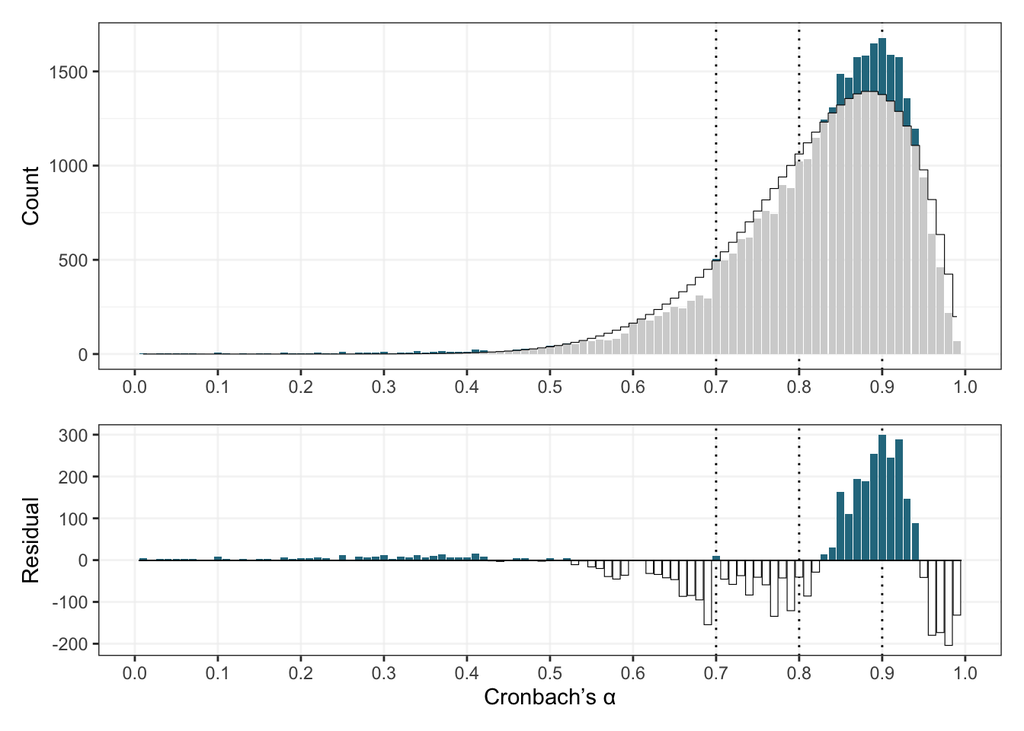

```r
beta_mu_intercept <- model_beta %>%
  tidy() %>%
  filter(component == "mean", term == "(Intercept)") %>%
  pull(estimate)

beta_phi_intercept <- model_beta %>%
  tidy() %>%
  filter(component == "precision", term == "(Intercept)") %>%
  pull(estimate)

data_frequency$density_beta <-
  extraDistr::dprop(x = data_frequency$alpha,
                    size = exp(beta_phi_intercept),
                    mean = plogis(beta_mu_intercept))

data_frequency <- data_frequency %>%
  mutate(residual_beta = freq*100 - density_beta,
         alpha = as.numeric(alpha),
         missing = ifelse(is.na(missing), FALSE, missing))

plot_data_psych_beta <- data_processed_trimmed |>
  mutate(n_total = n()) |>
  group_by(alpha) |>
  summarise(count = sum(!is.na(alpha))) |>
  mutate(type = case_when(alpha %in% c(.70, .80, .90) ~ "Common reliability threshold",
                          TRUE ~ "Non-threshold"),
         type = fct_relevel(type, "Non-threshold", "Common reliability threshold")) |>
  right_join(data_frequency, by = "alpha") |>
  mutate(excess = if_else(residual_beta > 0, "excess", "deficit")) %>%
  drop_na()

c_excess <- "#2A788EFF"
c_data <- "lightgrey"
c_line <- "black"
c_lpbg <- "white"
c_grid <- "#F0F0F0AA"

p1_beta <-
  ggplot(plot_data_psych_beta, aes(alpha, y = count, fill = excess)) +
  geom_vline(xintercept = c(0.7, 0.8, 0.9), linetype = "dotted") +
  geom_col() +
  geom_col(aes(y = count - if_else(residual_beta > 0, residual_beta * total_n, 0)), fill = c_data) +
  geom_step(aes(y = density_beta * total_n, group = 1), direction = "mid", size = 0.2, color = c_line) +
  scale_fill_manual(values = c(c_data, c_excess),
                    name = element_blank()) +
  scale_x_continuous(breaks = seq(from = 0, to = 1, by = 0.1),
                     labels = label_number(accuracy = 0.1),
                     minor_breaks = NULL) +
  theme_bw() +
  labs(x = "",
       y = "Count") +
  theme(axis.title.x = element_markdown()) +
  #ylim(0, 1800) +
  theme(legend.position = "none",
        legend.background = element_blank(),
        panel.grid = element_line(color = c_grid))

p2_beta <-
  ggplot(plot_data_psych_beta, aes(alpha, residual_beta * total_n, fill = excess)) +
  geom_vline(xintercept = c(0.7, 0.8, 0.9), linetype = "dotted") +
  geom_col(aes(color = excess), size = 0.2) +
  scale_color_manual(values = c(c_line, "#FFFFFF00")) +
  geom_segment(x = 0.005, xend = 0.995, y = 0,yend=0, size = 0.2, color = c_line) +
  scale_fill_manual(values = c("white", c_excess),
                    guide = guide_legend(reverse = TRUE)) +
  scale_x_continuous(breaks = seq(from = 0, to = 1, by = 0.1),
                     labels = label_number(accuracy = 0.1),
                     minor_breaks = NULL) +
  scale_y_continuous(breaks = seq(from = -200, to = 500, by = 100),
                     labels = label_number(accuracy = 1),
                     minor_breaks = NULL) +
  theme_bw() +
  labs(x = "Cronbach's &alpha;",
       y = "Residual") +
  theme(legend.title = element_blank(),
        axis.title.x = element_markdown(),
        legend.position = "none",
        panel.background = element_rect(fill = c_lpbg),
        panel.grid = element_line(color = c_grid))  # c(0.23, 0.77), legend.background = element_blank()

p_beta <- p1_beta + p2_beta + plot_layout(nrow = 2, heights = c(1.5, 1))

p_beta
```

```r
ggsave("plots/p_beta_psychology.pdf",
       plot = p_beta,
       device = cairo_pdf,
       width = 6,
       height = 4.5,
       units = "in")
```

## Quantify excess

```r
data_inflation_beta <- data_frequency %>%
  filter(missing == FALSE) %>%
  dplyr::select(alpha,
                observed = freq,
                predicted = density_beta,
                residual = residual_beta) %>%
  mutate(predicted = predicted/100,
         residual = residual/100,
         inflation = (observed/predicted - 1),
         inflation_for_reporting = janitor::round_half_up(inflation*100, digits = 0),
         group_3_cutoffs = as.factor(case_when(alpha %in% c(.70, .80, .90) ~ "cutoff",
                                               TRUE ~ "non cutoff")),
         group_1_cutoff = as.factor(case_when(alpha %in% c(.70) ~ "cutoff",
                                               TRUE ~ "non cutoff")))
```

- There were 2% more observations of Cronbach’s $a$ = .70 than predicted.
- There were -4% more observations of Cronbach’s $a$ = .80 than predicted.
- There were 22% more observations of Cronbach’s $a$ = .90 than predicted.

## Permutation test

.70, .80, and .90 against the rest:

```r
independence_test(residual ~ group_3_cutoffs,
                  data = data_inflation_beta,
                  distribution = "exact",
                  alternative = "greater")
```

```
##
##  Exact General Independence Test
##
## data:  residual by group_3_cutoffs (cutoff, non cutoff)
## Z = 1.8545, p-value = 0.05082
## alternative hypothesis: greater
```

.70 against the rest:

```r
independence_test(residual ~ group_1_cutoff,
                  data = data_inflation_beta,
                  distribution = "exact",
                  alternative = "greater")
```

```
##
##  Exact General Independence Test
##
## data:  residual by group_1_cutoff (cutoff, non cutoff)
## Z = 0.12121, p-value = 0.1875
## alternative hypothesis: greater
```

# Plots comparing kernel smoothing and caliper tests

## Full range

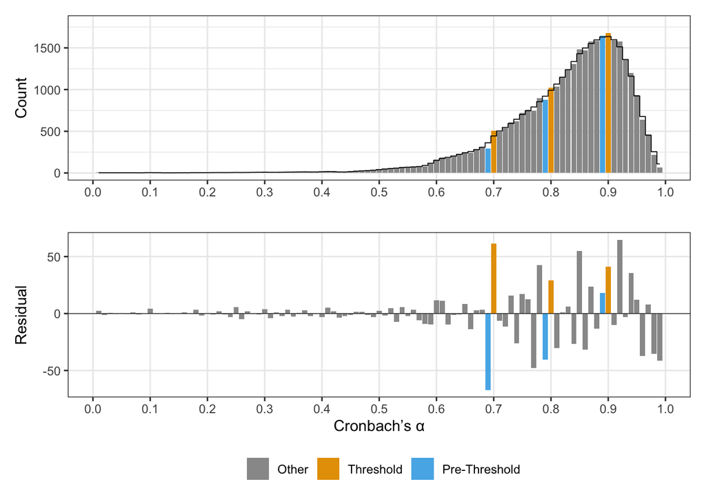

```r
cbp1 <- c("#999999", "#E69F00", "#56B4E9", "#009E73",
          "#F0E442", "#0072B2", "#D55E00", "#CC79A7")

plot_data <- data_processed_trimmed |>
  mutate(n_total = n()) |>
  group_by(alpha) |>
  summarise(count = sum(!is.na(alpha))) |>
  mutate(type = case_when(alpha %in% c(.70, .80, .90) ~ "Threshold",
                          alpha %in% c(.69, .79, .89) ~ "Pre-Threshold",
                          TRUE ~ "Other"),
         type = fct_relevel(type, "Other", "Pre-threshold", "Threshold")) |>
  right_join(data_frequency, by = "alpha") |>
  drop_na()

p1_kernel_alt <-
  ggplot(plot_data, aes(alpha, y = count, fill = type)) +
  #geom_vline(xintercept = c(0.7, 0.8, 0.9), linetype = "dotted") +
  geom_col(position = "stack") +
  geom_step(aes(y = density_kernel * total_n, group = 1), direction = "mid", size = 0.3) +
  #scale_fill_viridis_d(direction = -1, begin = 0.2, end = 0.65) +
  scale_fill_manual(values = cbp1) +
  scale_x_continuous(breaks = seq(from = 0, to = 1, by = 0.1),
                     labels = label_number(accuracy = 0.1),
                     minor_breaks = NULL) +
  # scale_alpha_manual(values = c("3" = 0.35, "2" = 1, "1" = 1)) +
  theme_bw() +
  labs(x = "", # expression("Cronbach's" ~ alpha),
       y = "Count",
       fill = "") +
  # theme(axis.title.x = element_markdown()) +
  ylim(0, 1800) +
  theme(legend.position = "none")

p2_kernel_alt <-
  ggplot(plot_data, aes(alpha, residual_kernel * total_n, fill = type)) +
  #geom_vline(xintercept = c(0.7, 0.8, 0.9), linetype = "dotted") +
  geom_col() +
  geom_hline(yintercept = 0, size = 0.2) +
  #scale_fill_manual(values = c("TRUE" = color_2, "FALSE" = color_1), guide = "none") +
  scale_fill_manual(values = cbp1) +
  scale_x_continuous(breaks = seq(from = 0, to = 1, by = 0.1),
                     labels = label_number(accuracy = 0.1),
                     minor_breaks = NULL) +
  scale_y_continuous(breaks = seq(from = -200, to = 200, by = 50),
                     labels = label_number(accuracy = 1),
                     minor_breaks = NULL) +
  theme_bw() +
  labs(x = "Cronbach's &alpha;",
       y = "Residual",
       fill = "") +
  theme(legend.position = "bottom",
        axis.title.x = element_markdown())

p_kernel_alt <- p1_kernel_alt + p2_kernel_alt + plot_layout(nrow = 2, heights = c(0.5, 0.5))

p_kernel_alt
```

```r
write_rds(p_kernel_alt, "plots/p_kernel_psychology_alt.rds")

# ggsave("plots/p_kernel_psychology_alt.pdf",
#        plot = p_kernel_alt,
#        device = cairo_pdf,
#        width = 6,
#        height = 4,
#        units = "in")
```

## Zoomed

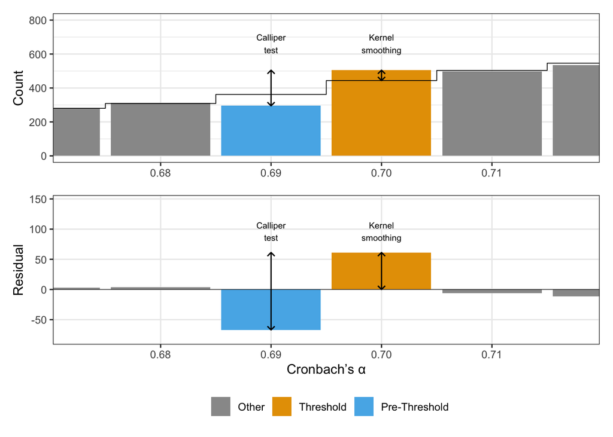

```r
p1_kernel_alt_zoom <-
  ggplot(plot_data, aes(alpha, y = count, fill = type)) +
  #geom_vline(xintercept = c(0.7, 0.8, 0.9), linetype = "dotted") +
  geom_col(position = "stack") +
  geom_step(aes(y = density_kernel * total_n, group = 1), direction = "mid", size = 0.3) +
  #scale_fill_viridis_d(direction = -1, begin = 0.2, end = 0.65) +
  scale_fill_manual(values = cbp1) +
  scale_x_continuous(breaks = seq(from = 0, to = 1, by = 0.01),
                     labels = label_number(accuracy = 0.01),
                     minor_breaks = NULL) +
  # scale_alpha_manual(values = c("3" = 0.35, "2" = 1, "1" = 1)) +
  theme_bw() +
  labs(x = "", # "Cronbach's &alpha;",
       y = "Count",
       fill = "") +
  ylim(0, 800) +
  theme(legend.position = "none",
        axis.title.x = element_markdown()) +
  coord_cartesian(xlim = c(.6725, .7175)) +
  annotate("text",
           x = .70,
           y = plot_data$count[plot_data$alpha == .70] + 120,
           label = "Kernel\nsmoothing\n",
           size = 2.5) +
  annotate("segment",
           x = .70,
           xend = .70,
           y = plot_data$count[plot_data$alpha == .70],  # observed counts
           yend = total_n * plot_data$density_kernel[plot_data$alpha == .70], # predicted counts
           arrow = arrow(ends = "both",
                         angle = 45,
                         length = unit(1.5,"mm"))) +
  annotate("text",
           x = .69,
           y = plot_data$count[plot_data$alpha == .70] + 120,
           label = "Calliper\ntest\n",
           size = 2.5) +
  annotate("segment",
           x = .69,
           xend = .69,
           y = plot_data$count[plot_data$alpha == .70],  # observed counts .70
           yend = plot_data$count[plot_data$alpha == .69], # observed counts .69
           arrow = arrow(ends = "both",
                         angle = 45,
                         length = unit(1.5,"mm")))

p2_kernel_alt_zoom <-
  ggplot(plot_data, aes(alpha, residual_kernel * total_n, fill = type)) +
  #geom_vline(xintercept = c(0.7, 0.8, 0.9), linetype = "dotted") +
  geom_col() +
  geom_hline(yintercept = 0, size = 0.2) +
  #scale_fill_manual(values = c("TRUE" = color_2, "FALSE" = color_1), guide = "none") +
  scale_fill_manual(values = cbp1) +
  scale_x_continuous(breaks = seq(from = 0, to = 1, by = 0.01),
                     labels = label_number(accuracy = 0.01),
                     minor_breaks = NULL) +
  scale_y_continuous(breaks = seq(from = -200, to = 200, by = 50),
                     labels = label_number(accuracy = 1),
                     minor_breaks = NULL) +
  theme_bw() +
  labs(x = "Cronbach's &alpha;",
       y = "Residual",
       fill = "") +
  theme(legend.position = "bottom",
        axis.title.x = element_markdown()) +
  coord_cartesian(xlim = c(.6725, .7175), ylim = c(-80, 145)) +
  annotate("text",
           x = .70,
           y = total_n * plot_data$residual_kernel[plot_data$alpha == .70] + 25,
           label = "Kernel\nsmoothing\n",
           size = 2.5) +
  annotate("segment",
           x = .70,
           xend = .70,
           y = 0,
           yend = total_n * plot_data$residual_kernel[plot_data$alpha == .70], # predicted counts
           arrow = arrow(ends = "both",
                         angle = 45,
                         length = unit(1.5,"mm"))) +
  annotate("text",
           x = .69,
           y = total_n * plot_data$residual_kernel[plot_data$alpha == .70] + 25,
           label = "Calliper\ntest\n",
           size = 2.5) +
  annotate("segment",
           x = .69,
           xend = .69,
           y = total_n * plot_data$residual_kernel[plot_data$alpha == .69],
           yend = total_n * plot_data$residual_kernel[plot_data$alpha == .70], # residual .69
           arrow = arrow(ends = "both",
                         angle = 45,
                         length = unit(1.5,"mm")))

p_kernel_alt_zoom <- p1_kernel_alt_zoom + p2_kernel_alt_zoom + plot_layout(nrow = 2, heights = c(0.5, 0.5))

p_kernel_alt_zoom
```

```r
ggsave("plots/p_kernel_method_comparison.pdf",
       plot = p_kernel_alt_zoom,
       device = cairo_pdf,
       width = 6,
       height = 4,
       units = "in")
```

## Combined

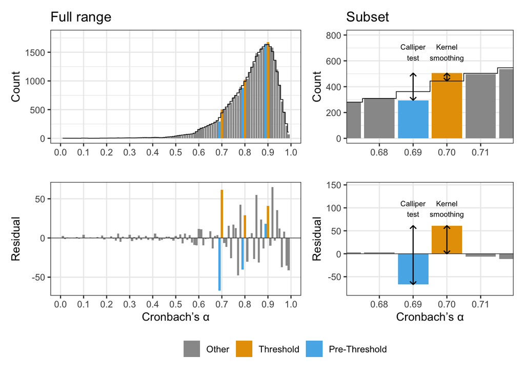

```r
(p1_kernel_alt + ggtitle("Full range")) +
  #(p1_kernel_alt_zoom + labs(title = "Subset around &alpha; = .70") + theme(plot.title = element_markdown())) +
  (p1_kernel_alt_zoom + ggtitle("Subset")) +
  p2_kernel_alt +
  p2_kernel_alt_zoom +
  plot_layout(nrow = 2, ncol = 2,
              widths = c(0.6, 0.4, 0.6, 0.4),
              guides = "collect") &
  theme(legend.position = 'bottom')
```